# Respuestas — Tarea 2 (Titanic)

Author

Ph D. Stephanie Hereira-Pacheco

Published

May 25, 2026

```r
titanic <- read.csv("https://raw.githubusercontent.com/datasciencedojo/datasets/master/titanic.csv")
```

## Parte 1: Exploración inicial

### 1. Explorar el dataset

```r
str(titanic)
```

```
'data.frame':   891 obs. of  12 variables:
 $ PassengerId: int  1 2 3 4 5 6 7 8 9 10 ...
 $ Survived   : int  0 1 1 1 0 0 0 0 1 1 ...
 $ Pclass     : int  3 1 3 1 3 3 1 3 3 2 ...
 $ Name       : chr  "Braund, Mr. Owen Harris" "Cumings, Mrs. John Bradley (Florence Briggs Thayer)" "Heikkinen, Miss. Laina" "Futrelle, Mrs. Jacques Heath (Lily May Peel)" ...
 $ Sex        : chr  "male" "female" "female" "female" ...
 $ Age        : num  22 38 26 35 35 NA 54 2 27 14 ...
 $ SibSp      : int  1 1 0 1 0 0 0 3 0 1 ...
 $ Parch      : int  0 0 0 0 0 0 0 1 2 0 ...
 $ Ticket     : chr  "A/5 21171" "PC 17599" "STON/O2. 3101282" "113803" ...
 $ Fare       : num  7.25 71.28 7.92 53.1 8.05 ...
 $ Cabin      : chr  "" "C85" "" "C123" ...
 $ Embarked   : chr  "S" "C" "S" "S" ...
```

```r
summary(titanic)
```

```
  PassengerId       Survived          Pclass          Name
 Min.   :  1.0   Min.   :0.0000   Min.   :1.000   Length:891
 1st Qu.:223.5   1st Qu.:0.0000   1st Qu.:2.000   Class :character
 Median :446.0   Median :0.0000   Median :3.000   Mode  :character
 Mean   :446.0   Mean   :0.3838   Mean   :2.309
 3rd Qu.:668.5   3rd Qu.:1.0000   3rd Qu.:3.000
 Max.   :891.0   Max.   :1.0000   Max.   :3.000

     Sex                 Age            SibSp           Parch
 Length:891         Min.   : 0.42   Min.   :0.000   Min.   :0.0000
 Class :character   1st Qu.:20.12   1st Qu.:0.000   1st Qu.:0.0000
 Mode  :character   Median :28.00   Median :0.000   Median :0.0000
                    Mean   :29.70   Mean   :0.523   Mean   :0.3816
                    3rd Qu.:38.00   3rd Qu.:1.000   3rd Qu.:0.0000
                    Max.   :80.00   Max.   :8.000   Max.   :6.0000
                    NA's   :177
    Ticket               Fare           Cabin             Embarked
 Length:891         Min.   :  0.00   Length:891         Length:891
 Class :character   1st Qu.:  7.91   Class :character   Class :character
 Mode  :character   Median : 14.45   Mode  :character   Mode  :character
                    Mean   : 32.20
                    3rd Qu.: 31.00
                    Max.   :512.33
```

```r
dim(titanic)
```

```
[1] 891  12
```

El dataset tiene **891 filas y 12 columnas**.

### 2. Convertir variables a factor

```r
titanic$Pclass <- factor(titanic$Pclass,
                         levels = c(1, 2, 3),
                         labels = c("Primera", "Segunda", "Tercera"))
titanic$Sex <- factor(titanic$Sex)
str(titanic[, c("Pclass", "Sex")])
```

```
'data.frame':   891 obs. of  2 variables:
 $ Pclass: Factor w/ 3 levels "Primera","Segunda",..: 3 1 3 1 3 3 1 3 3 2 ...
 $ Sex   : Factor w/ 2 levels "female","male": 2 1 1 1 2 2 2 2 1 1 ...
```

### 3. Pasajeros con dato de Age

```r
sum(!is.na(titanic$Age))
```

```
[1] 714
```

**714 pasajeros** tienen dato de edad (177 tienen NA).

## Parte 2: Estadísticos descriptivos

### 4. Estadísticos de Age y Fare

```r
# Age
mean(titanic$Age,   na.rm = TRUE)
```

```
[1] 29.69912
```

```r
median(titanic$Age, na.rm = TRUE)
```

```
[1] 28
```

```r
sd(titanic$Age,     na.rm = TRUE)
```

```
[1] 14.5265
```

```r
min(titanic$Age,    na.rm = TRUE)
```

```
[1] 0.42
```

```r
max(titanic$Age,    na.rm = TRUE)
```

```
[1] 80
```

```r
# Fare
mean(titanic$Fare)
```

```
[1] 32.20421
```

```r
median(titanic$Fare)
```

```
[1] 14.4542
```

```r
sd(titanic$Fare)
```

```
[1] 49.69343
```

```r
min(titanic$Fare)
```

```
[1] 0
```

```r
max(titanic$Fare)
```

```
[1] 512.3292
```

La media de `Fare` es mucho mayor que la mediana — señal de distribución muy sesgada hacia la derecha.

### 5. Boxplot de Fare por Pclass

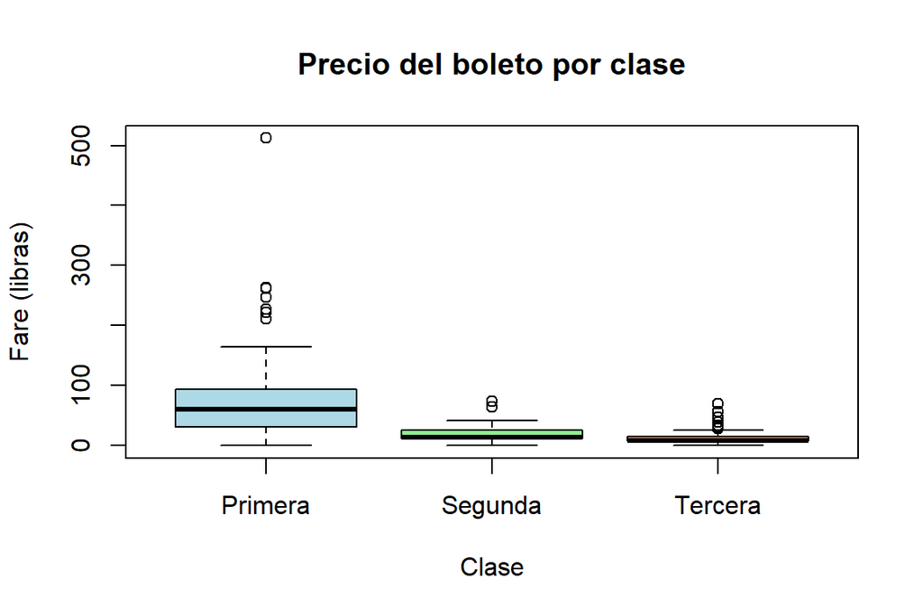

```r
boxplot(Fare ~ Pclass, data = titanic,
        main = "Precio del boleto por clase",
        xlab = "Clase", ylab = "Fare (libras)",
        col  = c("lightblue", "lightgreen", "lightsalmon"))
```

Los pasajeros de **primera clase** pagaron considerablemente más, con mayor variabilidad y varios valores atípicos muy elevados.

### 6. Boxplot de Age por Sex

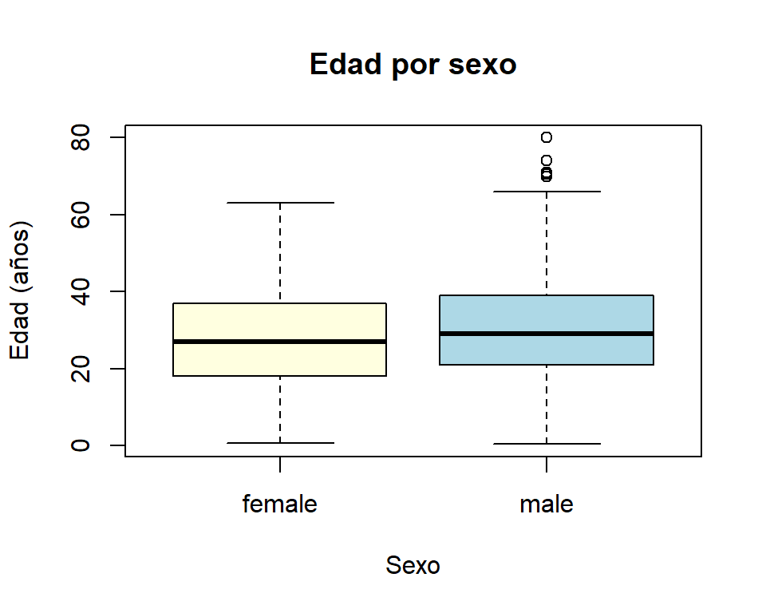

```r
boxplot(Age ~ Sex, data = titanic,
        main = "Edad por sexo",
        xlab = "Sexo", ylab = "Edad (años)",
        col  = c("lightyellow", "lightblue"))
```

Los hombres tienen una mediana de edad ligeramente mayor que las mujeres, aunque las distribuciones se solapan bastante.

## Parte 3: Normalidad

### 7. Shapiro-Wilk en Age y Fare

```r
Age_sin_na <- titanic$Age[!is.na(titanic$Age)]
shapiro.test(Age_sin_na)
```

```
    Shapiro-Wilk normality test

data:  Age_sin_na
W = 0.98146, p-value = 7.337e-08
```

```r
shapiro.test(titanic$Fare)
```

```
    Shapiro-Wilk normality test

data:  titanic$Fare
W = 0.52189, p-value < 2.2e-16
```

**Note**

**Age:** p-value < 0.05 → **no es normal**.

**Fare:** p-value << 0.05 → **no es normal** (distribución muy sesgada).

Conclusión: usaremos pruebas **no paramétricas** en las siguientes partes.

### 8. Q-Q plot de Fare

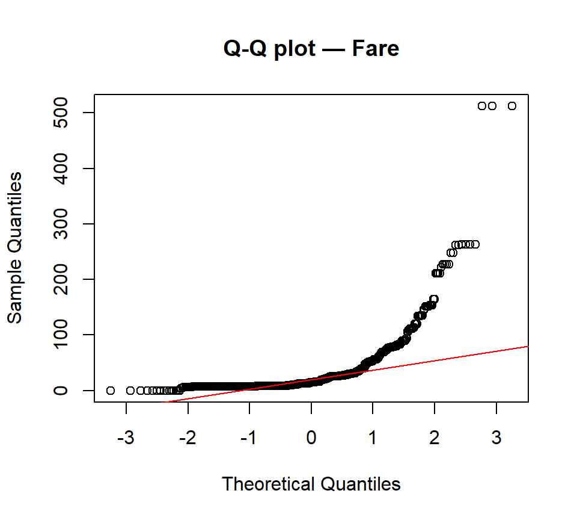

```r
qqnorm(titanic$Fare, main = "Q-Q plot — Fare")
qqline(titanic$Fare, col = "red")
```

Los puntos se alejan mucho de la línea diagonal, especialmente en los extremos — confirma que `Fare` **no sigue una distribución normal**.

## Parte 4: Pruebas estadísticas

### 9. ¿Difiere Fare entre clases? → Kruskal-Wallis

Como `Fare` no es normal, usamos la alternativa no paramétrica al ANOVA:

```r
kruskal.test(Fare ~ Pclass, data = titanic)
```

```
    Kruskal-Wallis rank sum test

data:  Fare by Pclass
Kruskal-Wallis chi-squared = 438.04, df = 2, p-value < 2.2e-16
```

**Note**

**p-value << 0.05** → hay diferencias significativas en el precio del boleto entre al menos dos clases. Lo observado en el boxplot (primera clase más cara) se confirma estadísticamente.

### 10. ¿Difiere Age entre hombres y mujeres? → Wilcoxon

Como `Age` no es normal, usamos `wilcox.test()`:

```r
wilcox.test(Age ~ Sex, data = titanic)
```

```
    Wilcoxon rank sum test with continuity correction

data:  Age by Sex
W = 53213, p-value = 0.02609
alternative hypothesis: true location shift is not equal to 0
```

**Note**

**p-value < 0.05** → hay una diferencia significativa en la edad entre hombres y mujeres en el Titanic.

### 11. Correlación entre Age y Fare → Spearman

Como ninguna de las dos variables es normal, usamos el método de Spearman:

```r
cor.test(titanic$Age, titanic$Fare,
         method = "spearman",
         use    = "complete.obs")
```

```
    Spearman's rank correlation rho

data:  titanic$Age and titanic$Fare
S = 52472641, p-value = 0.0002958
alternative hypothesis: true rho is not equal to 0
sample estimates:
      rho
0.1350512
```

## Parte 5: Regresión lineal

### 12. Regresión Fare ~ Age

```r
modelo <- lm(Fare ~ Age, data = titanic)
summary(modelo)
```

```
Call:
lm(formula = Fare ~ Age, data = titanic)

Residuals:
   Min     1Q Median     3Q    Max
-42.42 -24.49 -17.60   2.33 475.78

Coefficients:
            Estimate Std. Error t value Pr(>|t|)
(Intercept)  24.3009     4.4922   5.410 8.64e-08 ***
Age           0.3500     0.1359   2.575   0.0102 *
---
Signif. codes:  0 '***' 0.001 '**' 0.01 '*' 0.05 '.' 0.1 ' ' 1

Residual standard error: 52.71 on 712 degrees of freedom
  (177 observations deleted due to missingness)
Multiple R-squared:  0.009229,  Adjusted R-squared:  0.007837
F-statistic: 6.632 on 1 and 712 DF,  p-value: 0.01022
```